# ggplot: mini introduction

Tomasz Przechlewski  
email: t.plata-przechlewski@psw.kwidzyn.edu.pl  
affiliation: Powiślańska Szkoła Wyższa (Kwidzyn/Poland)

2024

# Data

It is expected by `ggplot2` that data is in long format. If it is in wide it is easy to transform it even on the fly..

My minimal set of external packages is:

```r
##library("ggplot2") ## charting functions bundled in tidyverse
library("tidyverse") ## data-manipulation
library("scales") ## scales
```

As a example I will use *Prevalence of obesity among adults* from WHO database

```r
obesity <- read.csv(file='obesity_who_all_C.csv', sep=';', header=T)
str(obesity)
```

```
## 'data.frame':    24571 obs. of  5 variables:
##  $ rok    : chr  "2016" "2016" "2016" "2015" ...
##  $ region : chr  "EMR" "EMR" "EMR" "EMR" ...
##  $ kraj   : chr  "AFG" "AFG" "AFG" "AFG" ...
##  $ plec   : chr  "BTSX" "FMLE" "MLE" "BTSX" ...
##  $ nadwaga: num  4.5 6.2 2.7 4.3 6 2.6 4.1 5.7 2.4 3.9 ...
```

The data is in long format and contains: year (`rok`), region (`region`), country (`kraj`) sex (`plec`), and BMI (`nadwaga`)

Variable `sex` has three values: `MLE`, `FMLE` and `BTSX` (both sexes combined)

# GGplot syntax

Looks complicated but it is not. All charts are constructed along the schema:

```
ggplot(df, aes(x= xcol, y=ycol  )) +
   geom_line( options ) ## line-plot, or
   geom_point (options) ## dot-plot, or
   geom_bar (options ) ## bar plot
```

where: `df` is a dataframe; ‘xcol’ is data for X-axis and `ycol` is data for Y-axis.

Example: to get one-dimensional data from `obesity` dataframe one has to filter it. Assume one wants to plot data for Poland with both sexes (F/M) combined:

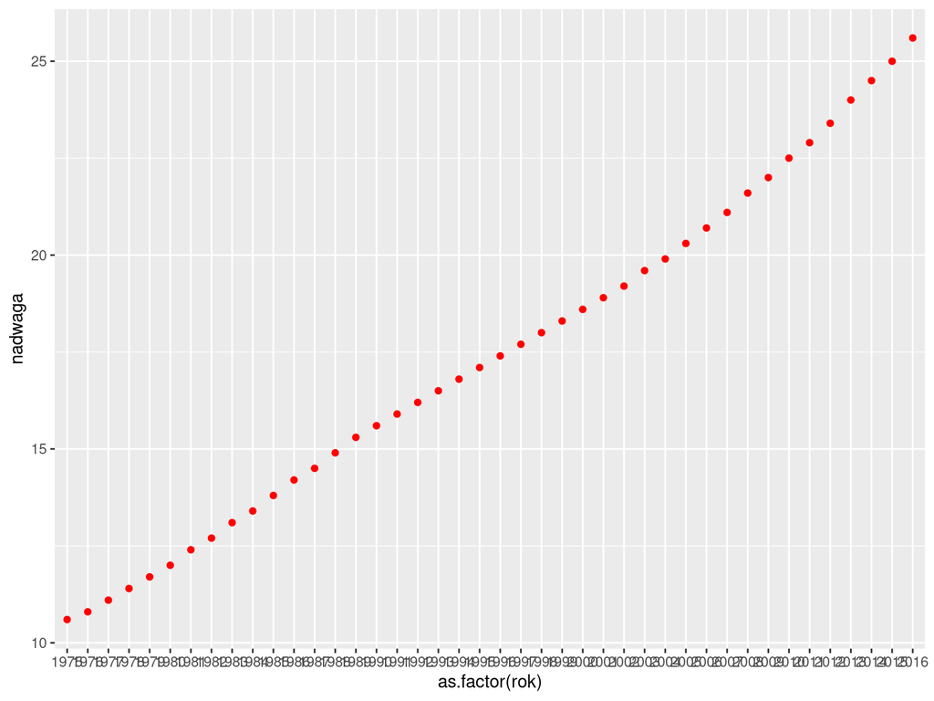

```r
obesityPL <- obesity %>% filter (kraj == 'POL' & plec == 'BTSX')
ggplot(obesityPL, aes(x= as.factor(rok), y=nadwaga, group=1 )) +
  geom_point(size=1.5, color='red' )
```

or

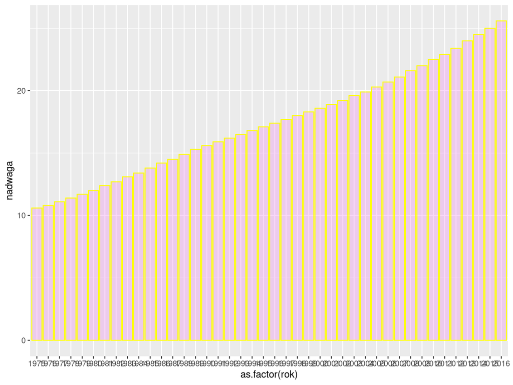

```r
ggplot(obesityPL, aes(x= as.factor(rok), y=nadwaga, group=1 )) +
  #geom_point(size=1.5, color='red' ) +
  geom_bar(stat="identity", alpha=.3, color='yellow', fill='violet')
```

or

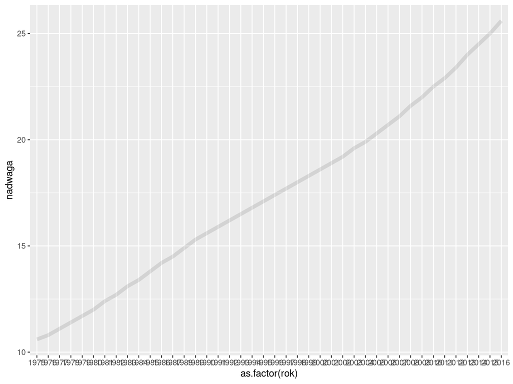

```r
ggplot(obesityPL, aes(x= as.factor(rok), y=nadwaga, group=1 )) +
  #geom_point(size=1.5, color='red' ) +
  #geom_bar(stat="identity", alpha=.3, color='yellow', fill='violet') +
  geom_line(size=2, alpha=.1)
```

# Line plot (time series)

BMI for Poland:

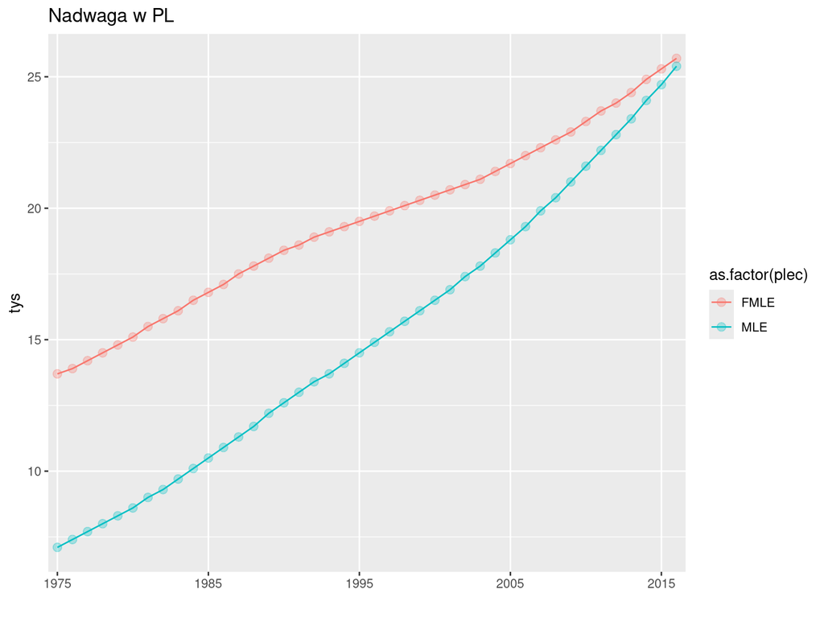

```r
## napierw filter z pakietu dpyr
## tylko kraj==POL; plec różna od BTSX
obesityPL <- obesity %>% filter (kraj == 'POL' & plec != 'BTSX')

## funkcja nth do pomijania pozycji na skali jeżeli jest ich za dużo
every_nth = function(n) {
  return(function(x) {x[c(TRUE, rep(FALSE, n - 1))]})
}

popl0 <- ggplot(obesityPL, aes(x= as.factor(rok),
        group=as.factor(plec), color=as.factor(plec), y=nadwaga )) +
  geom_line(size=.5 ) +
  geom_point(size=2.5, alpha=.3) +
  xlab(label="") +
  ## drukuj co 10 wartość
  scale_x_discrete( breaks = every_nth(n = 10)) +
  ylab(label="tys") +
  ##theme_nikw()+
  ggtitle("Nadwaga w PL")
popl0
```

better legend:

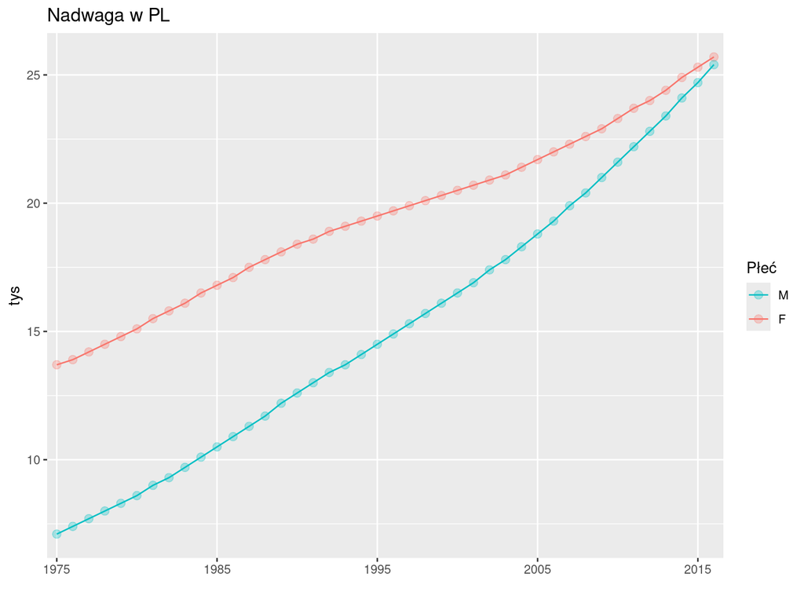

```r
popl1 <- popl0 +
scale_color_discrete(name="Płeć", labels =c("M", 'F'),
                       breaks=c('MLE', 'FMLE'))
popl1
```

Still better, convert `rok` to date and use appriopriate functions from `scales` package:

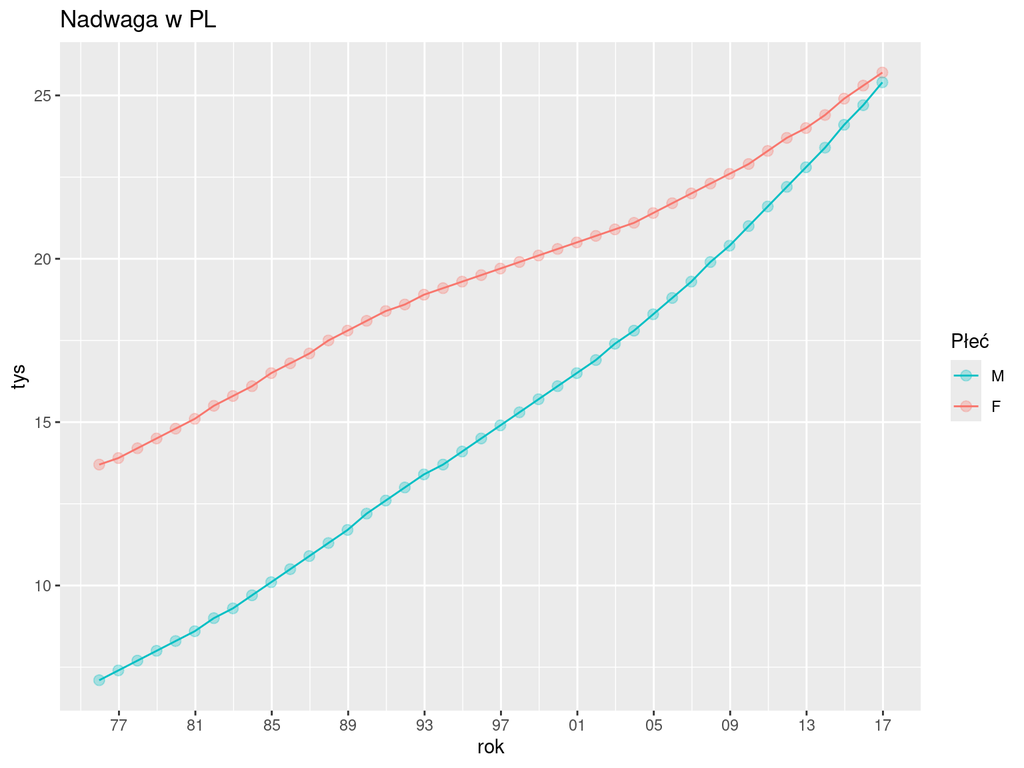

```r
popl2 <- ggplot(obesityPL, aes(x= as.Date(as.character(rok), "%Y"),
        group=as.factor(plec), color=as.factor(plec), y=nadwaga )) +
  geom_line(size=.5 ) + geom_point(size=2.5, alpha=.3) +
  ylab(label="tys") + xlab(label="rok") +
  ## %y to rok w notacji dwucyfrowej np. 21
  scale_x_date( breaks = "4 years", labels = date_format("%y")) +
  scale_color_discrete(name="Płeć", labels =c("M", 'F'),
                       breaks=c('MLE', 'FMLE')) +
  ggtitle("Nadwaga w PL")
popl2
```

Several countries

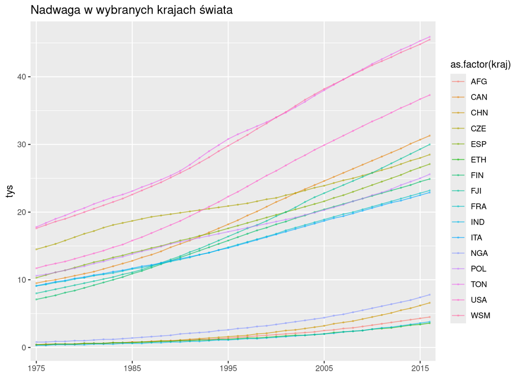

```r
countries <- c('POL', 'GER', 'ESP', 'CZE', 'ITA', 'FRA', 'FIN',
               'AFG', 'CHN', 'IND', 'NZA',
               'FJI', 'TON', 'WSM',
               'ETH', 'NGA', 'USA', 'CAN')
oo <- obesity %>% filter (plec == 'BTSX' & kraj %in% countries) %>%
  as.data.frame

poc <- ggplot(oo, aes(x= as.factor(rok),  group=as.factor(kraj),   color=as.factor(kraj), y=nadwaga )) +
  geom_line(size=.5, alpha=.6 ) +
  geom_point(size=.5, alpha=.3) +
  xlab(label="") +
  ylab(label="tys") +
  scale_x_discrete( breaks = every_nth(n = 10)) +
  ggtitle("Nadwaga w wybranych krajach świata")
poc
```

Many countries and both sexes

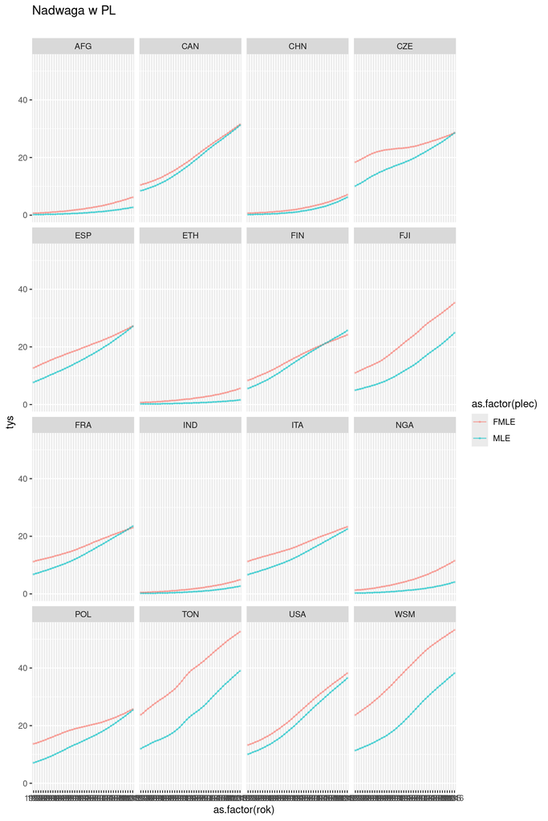

```r
ox <- obesity %>% filter (plec != 'BTSX' & kraj %in% countries) %>%
  as.data.frame

pox <- ggplot(ox, aes(x= as.factor(rok),
          group=as.factor(plec), color=as.factor(plec), y=nadwaga )) +
  geom_line(size=.5, alpha=.6 ) +
  geom_point(size=.5, alpha=.3) +
  ylab(label="tys") +
  facet_wrap( ~kraj, scales = "fixed") +
  ggtitle("Nadwaga w PL",
          subtitle=sprintf(""))
pox
```

# Combined point and bar plot

Two point plots plus bar plot for the difference

```r
obesity$yr <- as.numeric(as.character(obesity$rok))
```

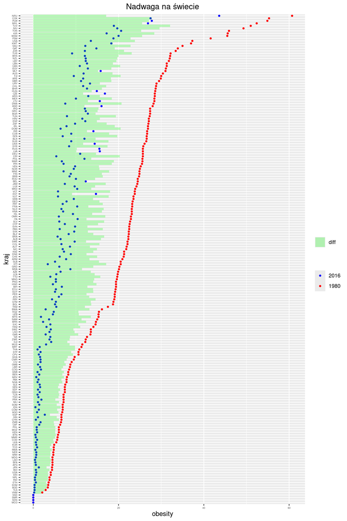

```r
obesity_diff <- obesity %>%
  filter (plec == 'BTSX' & yr > 1979 ) %>%
  group_by(kraj) %>%
  summarise(fst= nadwaga[which.min(yr)],
            lst = nadwaga[which.max(yr)],
            diff = nadwaga[which.max(yr)] - nadwaga[which.min(yr)])


poworld3 <- obesity_diff %>%
  ggplot(aes(x = reorder(kraj, lst ))) +
  geom_point(aes(y = lst, color="lst"), size=1 ) +
  geom_point(aes(y = fst, color="fst"), size=1 ) +
  geom_bar(aes(y = diff, fill='diff'), stat="identity", alpha=.25 ) +
  xlab(label="kraj") +
  ylab(label="obesity") +
  ggtitle("Nadwaga na świecie") +
  ##
  scale_color_manual(name="", labels =c("2016", "1980"),
                     values = c(lst="red", fst="blue" ) ) +
  scale_fill_manual(name="", values = c( diff="green" ) ) +
  #
  theme(axis.text = element_text(size = 4)) +
  theme(plot.title = element_text(hjust = 0.5)) +
  coord_flip()
poworld3
```

# Boxplot

Boxplots for 1980, 1990, 2000, and 2016

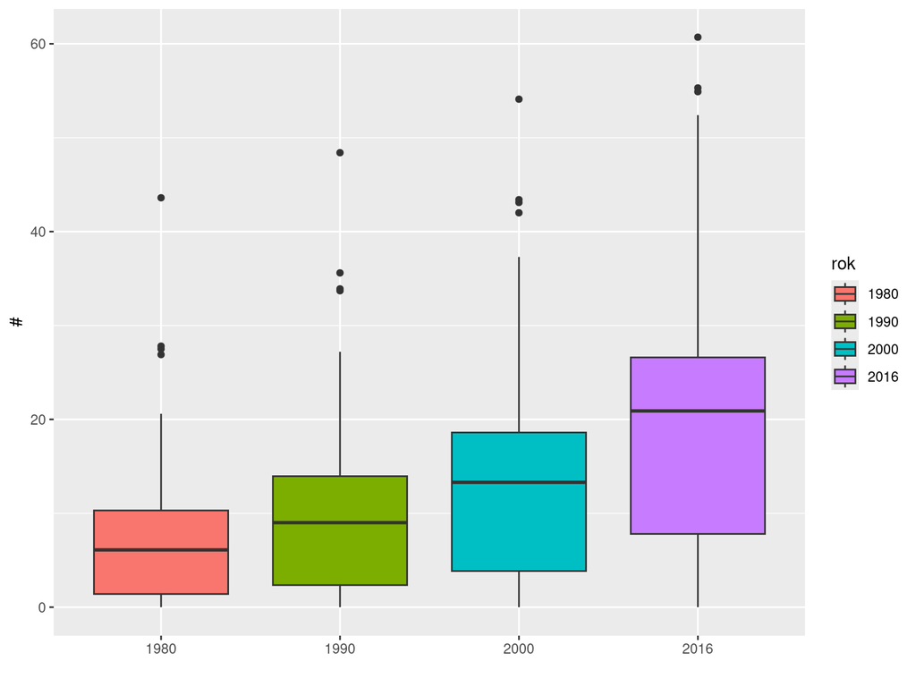

```r
lata <- c ('1980', '1990', '2000', '2016')
oz <- obesity %>% filter ((rok %in% lata ) & plec == 'BTSX')

pow <- ggplot(oz, aes(x=rok, y=nadwaga, fill=rok)) +
  geom_boxplot() +
  ylab("#") +
  xlab('')
pow
```